# data_visuvalization_car_crashes_ass2

```python
import pandas as pd
import matplotlib.pyplot as plt
import seaborn as sns
import plotly.express as px
```

```python
data:pd.DataFrame = sns.load_dataset('car_crashes')
data.head()
```

|  | total | speeding | alcohol | not_distracted | no_previous | ins_premium | ins_losses | abbrev |
| --- | --- | --- | --- | --- | --- | --- | --- | --- |
| 0 | 18.8 | 7.332 | 5.640 | 18.048 | 15.040 | 784.55 | 145.08 | AL |
| 1 | 18.1 | 7.421 | 4.525 | 16.290 | 17.014 | 1053.48 | 133.93 | AK |
| 2 | 18.6 | 6.510 | 5.208 | 15.624 | 17.856 | 899.47 | 110.35 | AZ |
| 3 | 22.4 | 4.032 | 5.824 | 21.056 | 21.280 | 827.34 | 142.39 | AR |
| 4 | 12.0 | 4.200 | 3.360 | 10.920 | 10.680 | 878.41 | 165.63 | CA |

```python
data.isnull().sum()
```

```
total             0
speeding          0
alcohol           0
not_distracted    0
no_previous       0
ins_premium       0
ins_losses        0
abbrev            0
dtype: int64
```

no nulls

#### Understanding columns in dataset

1. total - number of drivers involve in collisions per billion miles
2. speeding - percent of drivers involves in collisions due to speeding
3. alcohol - percent of drivers involves in collisions due to alcohol intake
4. not_distracted - percent of drivers involves in collisions who are not distracted
5. no_previous - percent of drivers involves in collisions for first time
6. ins_premiumn - premiumns for car
7. ins_losses - loss for insurence companies
8. abbrev - states

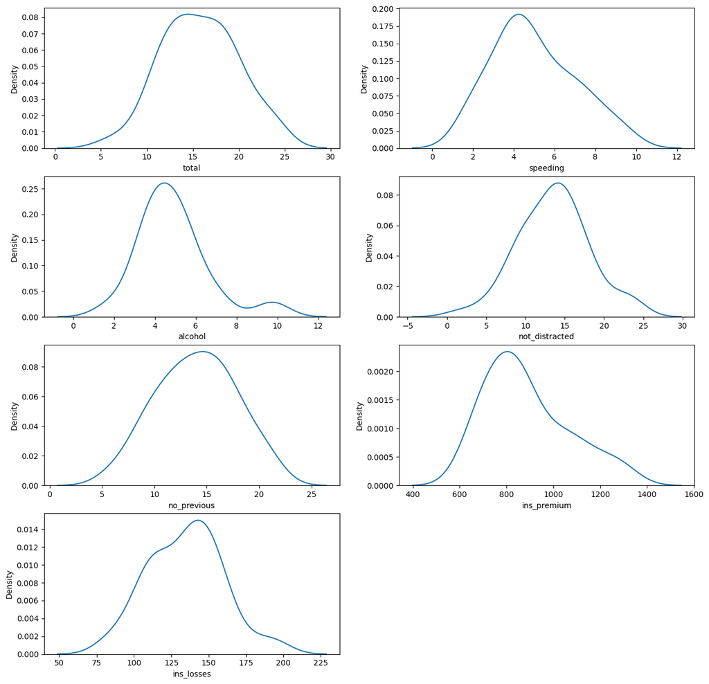

```python
j = 1
plt.figure(figsize=(15,15))
for i in data.drop(columns=['abbrev']):
    plt.subplot(4,2,j)
    plt.xlabel(i)
    sns.kdeplot(data = data[i])
    j += 1
plt.show()
```

We observe that the data exhibits a nearly normal distribution with a slight skewness in alcohol

```python
data.drop(columns=['abbrev']).skew()
```

```
total             0.041642
speeding          0.429957
alcohol           1.133296
not_distracted    0.017310
no_previous      -0.065635
ins_premium       0.778870
ins_losses        0.164100
dtype: float64
```

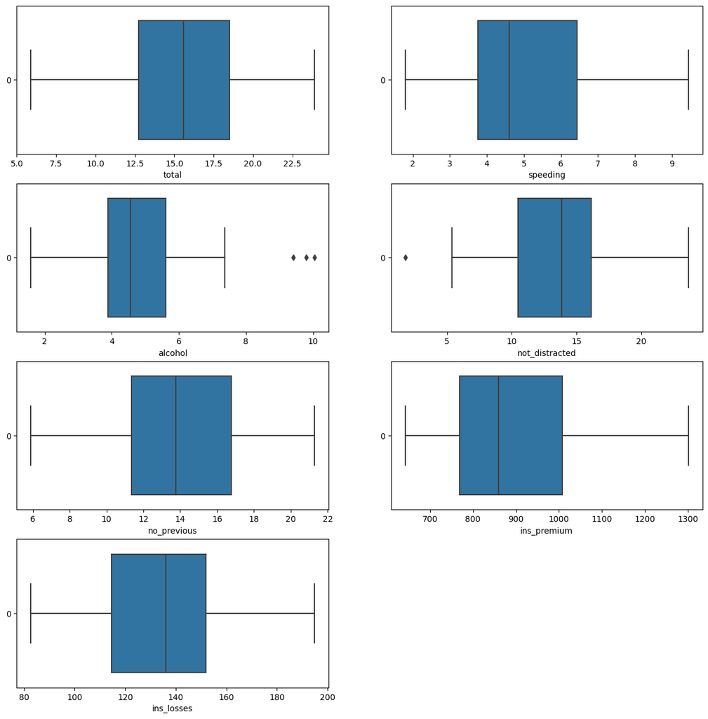

```python
j = 1
plt.figure(figsize=(15,15))
for i in data.drop(columns=['abbrev']):
    plt.subplot(4,2,j)
    plt.xlabel(i)
    sns.boxplot(data[i],orient='h')
    j += 1
plt.show()
```

Most of the data dont contain outliers

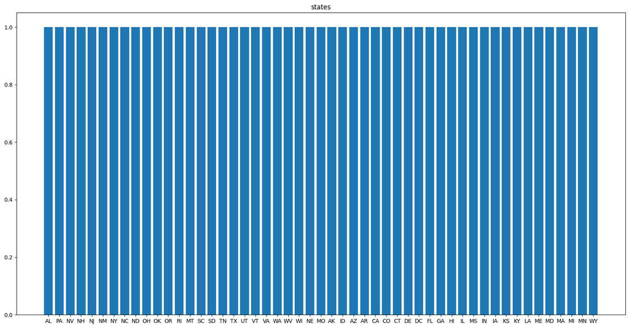

```python
plt.figure(figsize=(20,10))
plt.title('states')
plt.bar(data['abbrev'].value_counts().keys(),data['abbrev'].value_counts().values)
plt.show()
```

As observed each state in the dataset are equally repeated

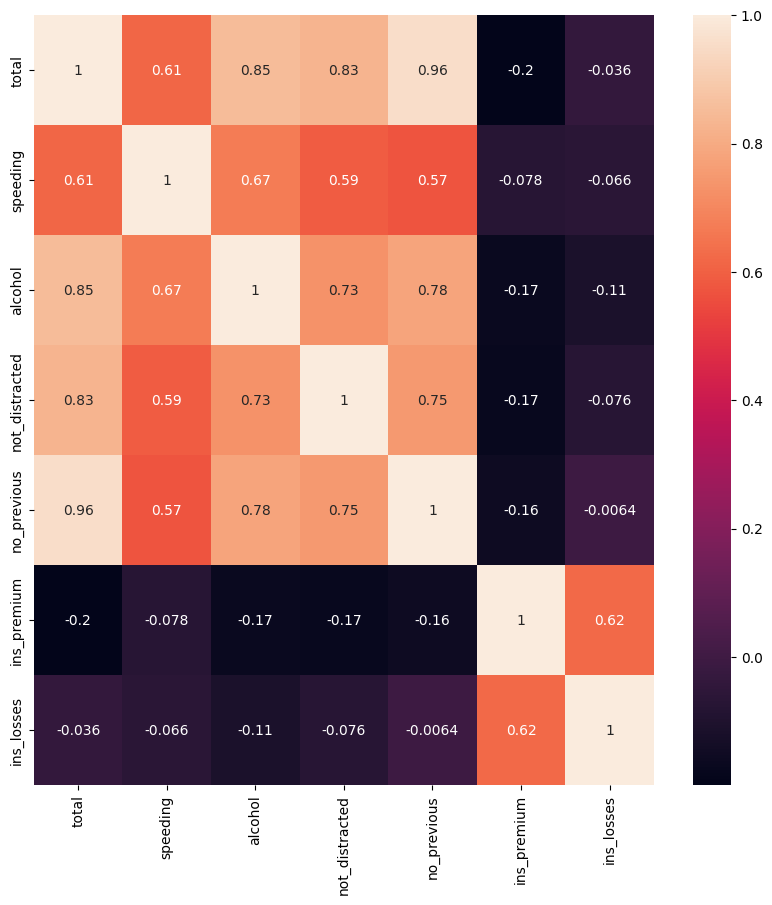

```python
plt.figure(figsize=(10,10))
sns.heatmap(data.drop(columns=['abbrev']).corr(),annot=True)
plt.show()
```

There exists linear relation b/w total vs alcohol , total vs not_distracted , total vs no_previous and there is either no relation b/w total , ins_losses , total vs ins_premium or complex relationship

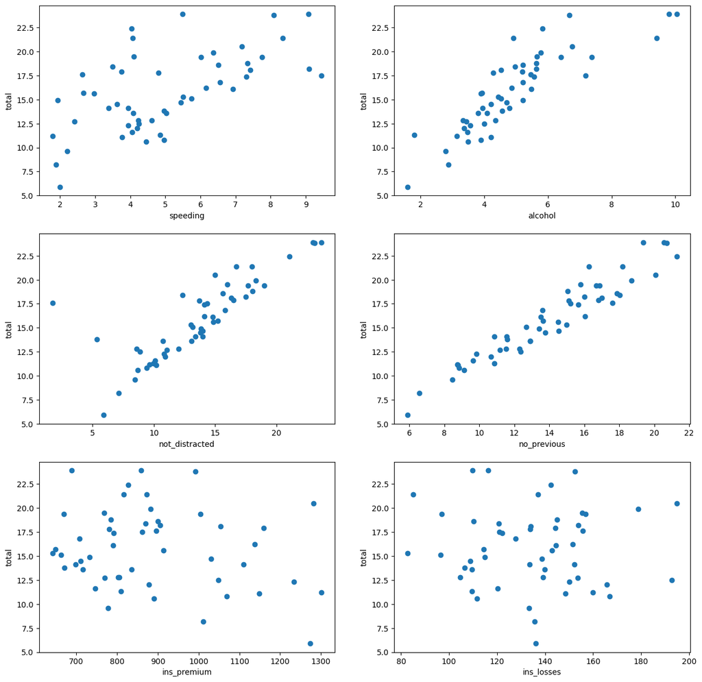

```python
j = 1
plt.figure(figsize=(15,15))
for i in data.drop(columns=['abbrev','total']):
    plt.subplot(3,2,j)
    plt.xlabel(i)
    plt.ylabel('total')
    plt.scatter(data[i],data['total'])
    j += 1
plt.show()
```

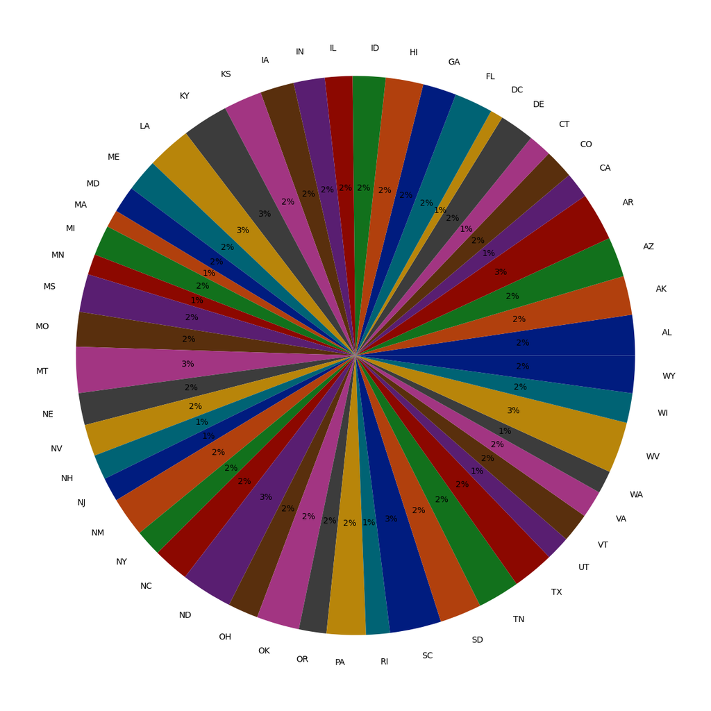

```python
colors = sns.color_palette('dark')
plt.figure(figsize=(15,15))
plt.pie(data['total'],labels=data['abbrev'],autopct="%.0f%%",colors=colors)
plt.show()
```

we observe distribution for total no of accidents pere each sate is similar which occupis form 1 to 3 percentage

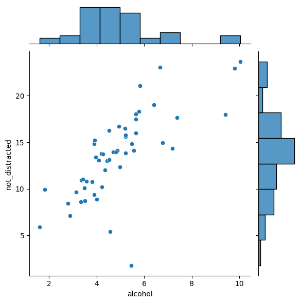

```python
sns.jointplot(x = 'alcohol', y='not_distracted',data=data[['alcohol','not_distracted']],kind='scatter')
plt.show()
```

alcohol and not_distracted are linearly distributed approximatley  
and there existis few no of outliers in alcohol

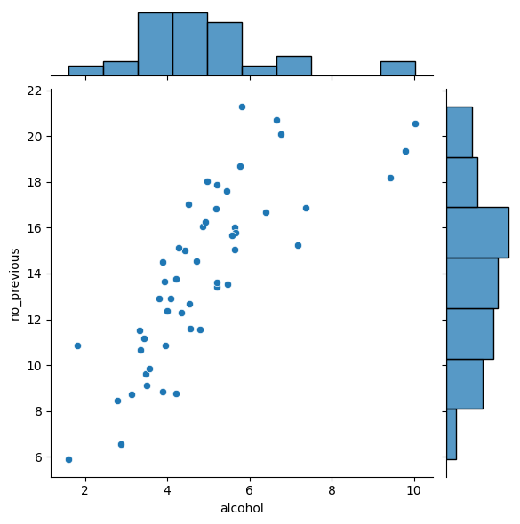

```python
sns.jointplot(x = 'alcohol', y='no_previous',data=data[['alcohol','no_previous']],kind='scatter')
plt.show()
```

alcohol and no_previous are linearly distributed approximatley  
and there existis few no of outliers in alcohol

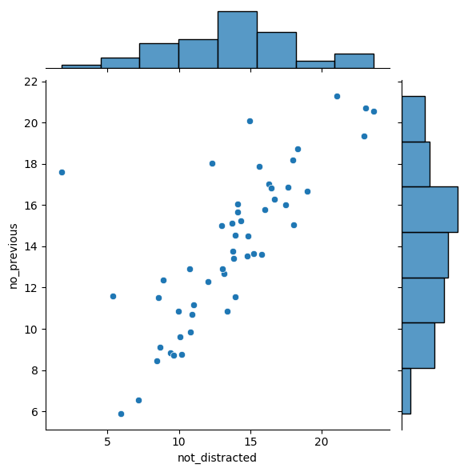

```python
sns.jointplot(x = 'not_distracted', y='no_previous',data=data[['not_distracted','no_previous']],kind='scatter')
plt.show()
```

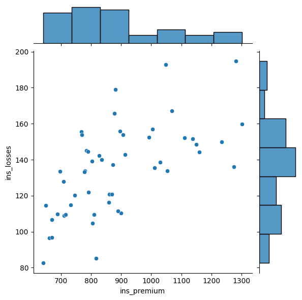

```python
sns.jointplot(x = 'ins_premium', y='ins_losses',data=data[['ins_premium','ins_losses']],kind='scatter')
plt.show()
```

ins_premium and ins_losses is moderatly related to each other

[output not shown]

[output cut: 9 more lines]

[output not shown]

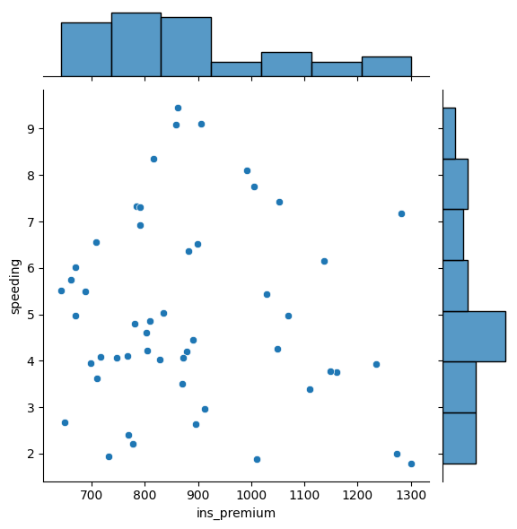

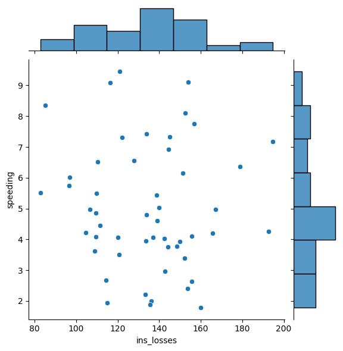

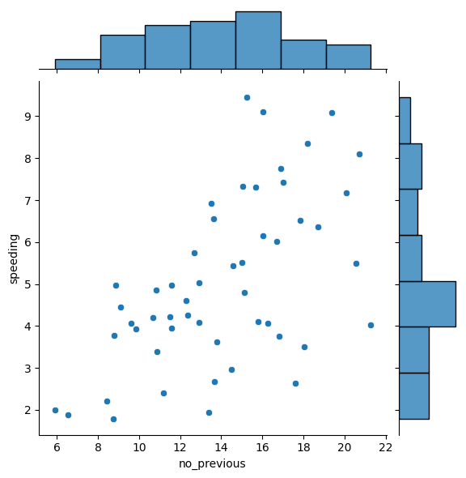

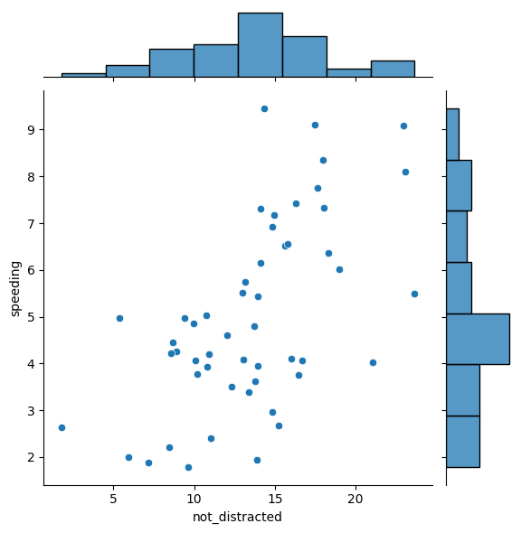

```python
lis = ['ins_premium','ins_losses','no_previous','not_distracted']
j = 1
for i in lis:
    sns.jointplot(x = i, y='speeding',data=data,kind='scatter')
    j += 1
```

as observed speeding is not strongly linearly related to most of the stuff,corr is around 0.5 excluding the ins_premium , ins_losses

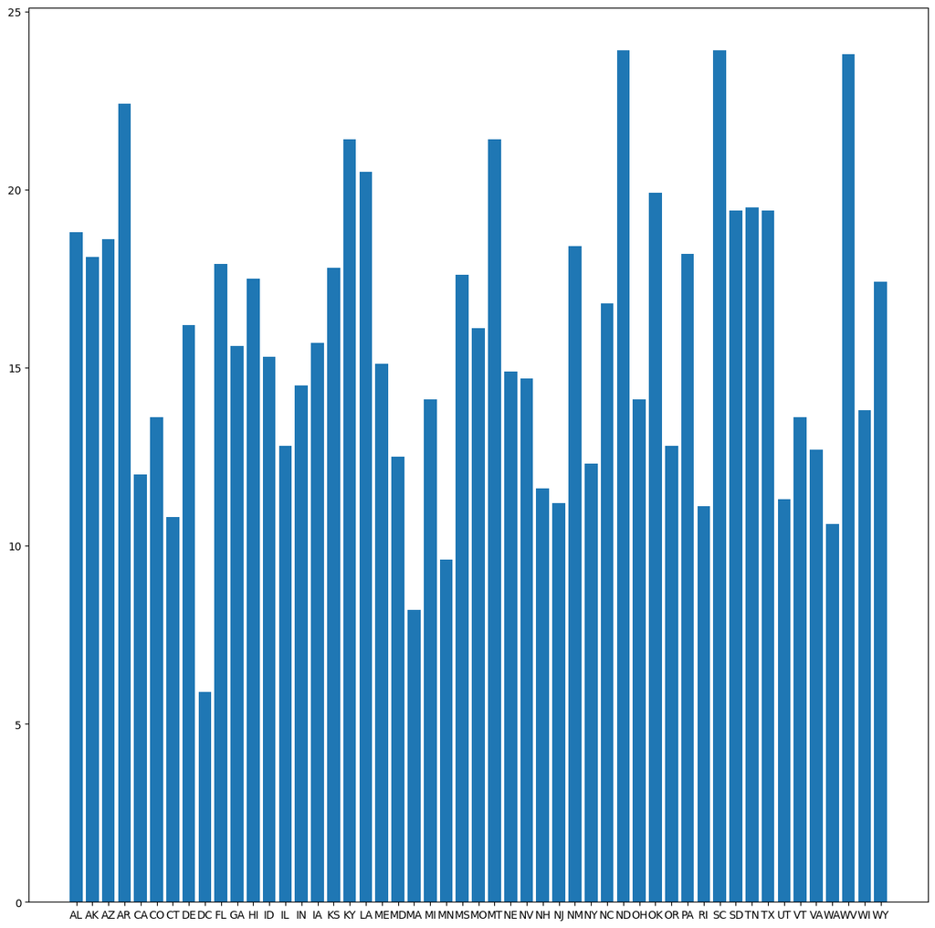

```python
plt.figure(figsize=(15,15))
plt.bar(x = data['abbrev'],height= data['total'])
plt.show()
```

ND,SC,WV has highest number of accidents

as per initial observation if we want to include ins_premium or ins_losses its better to chose random forest regressor or we can excludde ins_premium or inslosses and can apply the multivariate linear regression it will just give the good results base on correlation analasys and to observe the relation of categorial column we need to do hypothesis testing to know the relationship